# Normalisation

Runs differ in how much protein was loaded and how well the instrument ran that day. Cyclic loess removes those intensity-dependent differences so the 45 runs can be compared protein by protein. Missing values stay missing: `03_Quantification` models them, and blood enters every later model as a covariate.

## Packages

proteoDA supplies the normalisation and its standard reports. limma supplies the linear model used for the variance check.

```r
library(here)
library(proteoDA)
library(dplyr)
library(tibble)
library(limma)
library(ggplot2)
source(here("00_Setup", "Shared_functions", "analysis_reporting_helpers.R"))
```

## Input

The input is the filtered `DAList` from `01_Protein_Filtering`: raw intensities with `NA` where a protein was not detected.

```r
inputs <- c(filtered = "01_Processing/01_Protein_Filtering/c_data/DAList_filtered.rds")
paths <- vapply(inputs, here, character(1))
stopifnot(file.exists(paths))
dal <- readRDS(paths[["filtered"]])
out <- here("01_Processing", "02_Normalisation", "c_data")
reports <- here("01_Processing", "02_Normalisation", "b_reports")
for (path in c(out, reports)) dir.create(path, recursive = TRUE, showWarnings = FALSE)

dim(dal$data)
```

```
[1] 1900   45
```

```r
dal$data[1:3, 1:4]
```

```
             S03_T1   S10_T1   S16_T1   S22_T1
A0A0B4J2D5 57551800 44869800 43107400 41025000
A0FGR8           NA       NA       NA       NA
A1L0T0           NA       NA       NA   120296
```

## Cyclic loess

Cyclic loess (Bolstad et al. 2003) takes every pair of runs, plots their log2 difference against their mean intensity, fits a smooth curve through that cloud, and subtracts the curve. After a few cycles no pair of runs differs systematically at any intensity. This is limma’s `normalizeCyclicLoess()`, called by proteoDA with `method = "fast"` (each run against the average run) and limma’s default adaptive span, so the curve’s smoothness follows the protein count (package behaviour). `normalize_data()` log2-transforms the raw intensities first; the `before` matrix is logged here so the two can be compared on one scale.

proteoDA’s reports go to `b_reports/`: `norm_comparison.pdf` scores every normalisation method it offers, and `qc_pre.pdf` and `qc_post.pdf` show run-level QC before and after. The functions also draw to the screen; a null device swallows that copy so it does not land in `Rplots.pdf`.

Choosing cyclic loess is a project decision. The manuscript’s pipeline chose it independently, after comparing eight methods on pooled coefficient of variation, median absolute deviation and inter-run correlation. This repository holds no record of its own comparison beyond `norm_comparison.pdf`.

```r
pdf(NULL)
write_norm_report(dal,
  grouping_column = "group_time", output_dir = reports,
  filename = "norm_comparison.pdf", overwrite = TRUE
)
write_qc_report(dal,
  color_column = "group_time", output_dir = reports,
  filename = "qc_pre.pdf", overwrite = TRUE
)
before <- log2(as.matrix(dal$data))
dal <- normalize_data(dal, norm_method = "cycloess")
write_qc_report(dal,
  color_column = "group_time", output_dir = reports,
  filename = "qc_post.pdf", overwrite = TRUE
)
invisible(dev.off())
stopifnot(identical(dal$metadata$sample_id, colnames(dal$data)))
```

The same three proteins in the same four runs, before and after. Missing cells stay missing.

```r
round(before[1:3, 1:4], 2)
```

```
           S03_T1 S10_T1 S16_T1 S22_T1
A0A0B4J2D5  25.78  25.42  25.36  25.29
A0FGR8         NA     NA     NA     NA
A1L0T0         NA     NA     NA  16.88
```

```r
round(as.matrix(dal$data)[1:3, 1:4], 2)
```

```
           S03_T1 S10_T1 S16_T1 S22_T1
A0A0B4J2D5  25.77   25.2  25.34  25.89
A0FGR8         NA     NA     NA     NA
A1L0T0         NA     NA     NA  16.90
```

```r
intensity_quantiles <- function(values, stage) {
  probs <- c(0.05, 0.25, 0.5, 0.75, 0.95)
  qs <- apply(values, 2, quantile, probs = probs, na.rm = TRUE)
  tibble(
    stage = stage, sample_id = colnames(values),
    q05 = qs[1, ], q25 = qs[2, ], q50 = qs[3, ], q75 = qs[4, ], q95 = qs[5, ]
  )
}
stopifnot(identical(colnames(before), colnames(dal$data)))
quantiles <- bind_rows(
  intensity_quantiles(before, "before"), intensity_quantiles(as.matrix(dal$data), "after")
) |>
  left_join(select(dal$metadata, sample_id, group, timepoint), by = "sample_id")
quantiles |>
  group_by(stage) |>
  summarise(median_of_run_medians = median(q50), spread_of_run_medians = diff(range(q50)))
```

```
# A tibble: 2 × 3
  stage  median_of_run_medians spread_of_run_medians
  <chr>                  <dbl>                 <dbl>
1 after                   20.6                  1.09
2 before                  20.6                  1.09
```

## How much of each protein’s variance the design explains

```r
cell_fit <- lmFit(dal$data, model.matrix(~group_time, dal$metadata))
total_ss <- apply(dal$data, 1, \(x) sum((x - mean(x, na.rm = TRUE))^2, na.rm = TRUE))
eta2 <- 1 - cell_fit$sigma^2 * cell_fit$df.residual / total_ss
eta2[rowSums(!is.na(dal$data)) < 4] <- NA
summary(eta2)
```

```
    Min.  1st Qu.   Median     Mean  3rd Qu.     Max.
0.004987 0.077628 0.123007 0.144774 0.187050 0.812998
```

## Runs after normalisation

Principal component analysis (PCA) needs a complete matrix, so each run’s gaps are filled with that run’s median, for this picture only. The saved matrix keeps them missing.

```r
filled <- apply(dal$data, 2, \(x) replace(x, is.na(x), median(x, na.rm = TRUE)))
pca <- prcomp(t(filled), center = TRUE, scale. = TRUE)
components <- tibble(
  component = paste0("PC", 1:4),
  variance_explained = round(summary(pca)$importance[2, 1:4], 3)
)
pca_scores <- as_tibble(pca$x[, 1:2], rownames = "sample_id") |>
  left_join(dal$metadata, by = "sample_id")
components
```

```
# A tibble: 4 × 2
  component variance_explained
  <chr>                  <dbl>
1 PC1                    0.116
2 PC2                    0.102
3 PC3                    0.073
4 PC4                    0.06
```

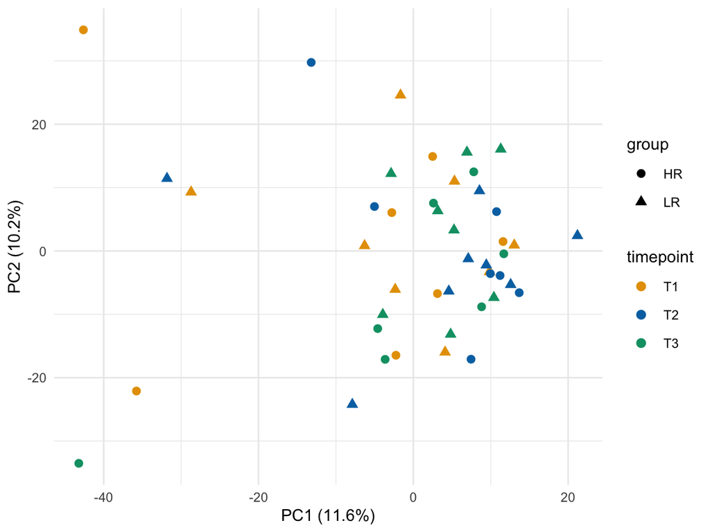

Figure 1: Runs on the first two principal components after normalisation, gaps median-filled.

```r
ggplot(pca_scores, aes(PC1, PC2, colour = timepoint, shape = group)) +
  geom_point(size = 2.2) +
  scale_colour_manual(values = c(T1 = "#E69F00", T2 = "#0072B2", T3 = "#009E73")) +
  labs(
    x = sprintf("PC1 (%.1f%%)", 100 * components$variance_explained[1]),
    y = sprintf("PC2 (%.1f%%)", 100 * components$variance_explained[2])
  ) +
  theme_minimal(base_size = 10)
```

## Summary

1900 proteins in 45 runs were normalised. The six group-by-time cells explain a median 12% of a protein’s variance. PC1 and PC2 carry 11.6% and 10.2% of the variance.

## Save

`DAList_normalized.rds` is the input to `03_Quantification` and `04_Gene_Sets`; the workbook is read by `05_Figures/Processing/S01_QC`.

```r
saveRDS(dal, file.path(out, "DAList_normalized.rds"), compress = "xz")
sheets <- list(
  normalized = bind_cols(
    as_tibble(dal$annotation) |> select(uniprot_id, protein, gene, description),
    as_tibble(dal$data)
  ),
  components = components,
  pca_scores = select(pca_scores, sample_id, subject, group, timepoint, PC1, PC2),
  eta_squared = tibble(uniprot_id = rownames(dal$data), eta2 = unname(eta2)),
  intensity_quantiles = quantiles
)
holds <- c(
  "Cyclic-loess log2 abundance, one row per protein.",
  "Variance explained by the first four principal components.",
  "Each sample's PC1 and PC2 score.",
  "Share of each protein's variance explained by the six group cells.",
  "Each sample's log2 intensity quantiles (5, 25, 50, 75, 95%) before and after cyclic loess."
)
write_workbook(sheets, holds, file.path(out, "normalisation.xlsx"), inputs, paths)
```